# A Bayesian mixed model, end to end

Fitting the sleepstudy reaction-time model with flexyBayes, and handing the answer to a colleague

Published

2026-06-29

Abstract

A worked example of `flexyBayes` on a real, public data set. A statistician specifies a linear mixed model once, in ASReml-style syntax, and fits it through a Bayesian back end. A sleep researcher who does not write models receives the fitted result and reads a direct answer to one question: how fast does reaction time degrade under sleep restriction, and how certain are we? Every number below is computed at render time from the public sleepstudy data.

## 0.1 What this document is

> The figures and numbers below come from the **sleepstudy** data set, a public study of reaction time under sleep restriction (Belenky et al., 2003). The data ship with the `lme4` package and are reused here under that package’s licence (GPL). They are real measurements, used to illustrate the `flexyBayes` workflow.

`flexyBayes` lets you write a mixed model once and fit it through a choice of Bayesian engines. This walkthrough takes one model from specification to a usable answer, played by two people in turn:

1. **The statistician** specifies and fits the model, then reads the posterior.
2. **The sleep researcher** receives the fitted result and asks one applied question of it, without writing any model code.

**Tip**

**Why read this?** It shows the shortest honest path from a research question to a quantified answer with a stated uncertainty, using a single model specification that can be fitted three different ways for cross-checking.

A few abbreviations are used throughout. A **linear mixed model (LMM)** is a regression with both population-level slopes (fixed effects) and group-level deviations (random effects). The **posterior** is the distribution of a parameter after combining the data with a prior, and a **credible interval** is a range that contains the parameter with a stated probability. The package fits the model through the **integrated nested Laplace approximation (INLA)** (Rue et al., 2009), a deterministic approximation, and can also use sampling engines based on **Hamiltonian Monte Carlo (HMC)**.

**Requirements (for the statistician who re-renders this).** R, plus `flexyBayes` and the engine it uses here:

```r
install.packages("flexyBayes")     # the package
install.packages("INLA", repos = c(INLA = "https://inla.r-inla-download.org/R/stable"))
install.packages("lme4")           # the data set, and the cross-check fit
```

The sleep researcher in the second half needs none of this. They receive a small result file and read it.

# 1 The statistician’s side

## 1.1 The question and the data

Eighteen subjects had their sleep restricted to three hours a night. Their reaction time, in milliseconds, was measured once a day for ten days. The question is simple to state: **on average, how much does reaction time worsen per day of restriction, and how confident can we be in that rate?**

```r
str(sleepstudy)
```

```
#> 'data.frame':    180 obs. of  3 variables:
#>  $ Reaction: num  250 259 251 321 357 ...
#>  $ Days    : num  0 1 2 3 4 5 6 7 8 9 ...
#>  $ Subject : Factor w/ 18 levels "308","309","310",..: 1 1 1 1 1 1 1 1 1 1 ...
```

Each subject contributes ten measurements, so the ten readings from one person are correlated. A plain regression that ignored this would understate the uncertainty. The right structure is a linear mixed model with a population trend in `Days` and a per-subject random intercept that absorbs each person’s own baseline.

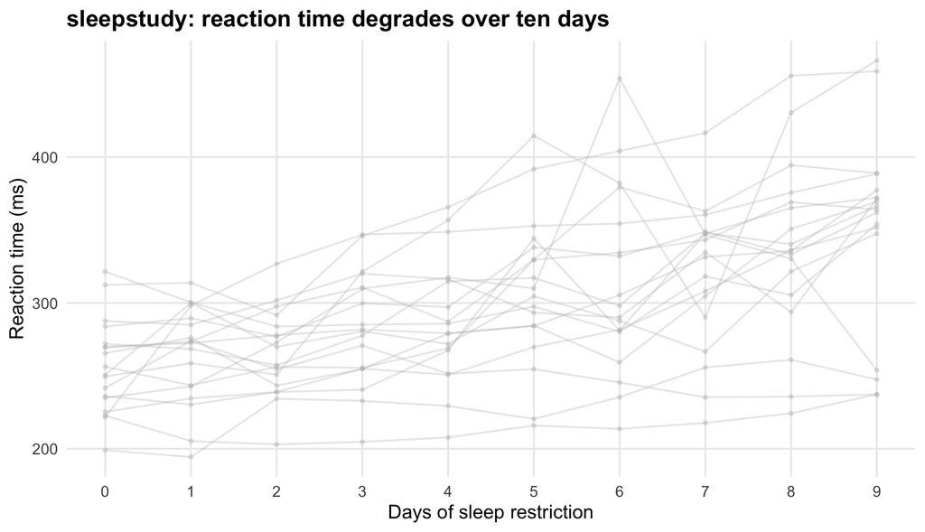

Reaction time against days of sleep restriction. Each thin line is one subject; the upward trend is the population effect the model estimates.

```r
ggplot(sleepstudy, aes(Days, Reaction, group = Subject)) +
  geom_line(alpha = 0.35, colour = grey_ln) +
  geom_point(alpha = 0.35, colour = grey_ln, size = 0.8) +
  scale_x_continuous(breaks = 0:9) +
  labs(x = "Days of sleep restriction", y = "Reaction time (ms)",
       title = "sleepstudy: reaction time degrades over ten days") +
  theme_wt()
```

## 1.2 One specification

`flexyBayes` takes the model in ASReml-style syntax: a `fixed` part for the population trend, a `random` part for the per-subject intercept. The back end is chosen with one argument.

```r
fit <- flexybayes(
  fixed   = Reaction ~ Days,
  random  = ~ Subject,
  data    = sleepstudy,
  family  = "gaussian",
  backend = "inla",
  verbose = FALSE, mcmc_verbose = FALSE
)
```

The same specification can be fitted through three engines by changing one word: `backend = "inla"` (the deterministic approximation used here), `backend = "greta"` (Hamiltonian Monte Carlo on TensorFlow), or `backend = "brms"` (Hamiltonian Monte Carlo through Stan). Fitting the model more than one way and confirming the answers agree is a built-in robustness check; a companion validation study confirms the three engines agree on this model to within sampling tolerance.

## 1.3 Reading the posterior

The fitted object summarises the fixed effects as a posterior mean and a 95 per cent credible interval for each term.

```r
s   <- summary(fit)
```

```
#> Bayesian fit summary  [flexybayes_inla / INLA backend]
#> ------------------------------------------------------------
#> Fixed effects:
#>                 mean     sd 0.025quant 0.5quant 0.975quant     mode kld
#> (Intercept) 251.4795 6.7123   238.3051 251.4792   264.6561 251.4792   0
#> Days         10.4507 1.2570     7.9831  10.4508    12.9179  10.4508   0
#>
#> Hyperparameters:
#>                                                 mean           sd  0.025quant
#> Precision for the Gaussian observations 5.000000e-04 1.000000e-04 4.00000e-04
#> Precision for Subject                   8.509333e+10 7.929682e+10 1.61673e+10
#>                                             0.5quant   0.975quant        mode
#> Precision for the Gaussian observations 5.000000e-04 6.000000e-04 4.00000e-04
#> Precision for Subject                   6.217781e+10 2.955598e+11 3.62784e+10
#>
#> Random effects:
#>   groups: Subject
#> ------------------------------------------------------------
```

```r
fx  <- s$fixed
days_row <- fx["Days", ]
post <- data.frame(
  Term = rownames(fx),
  `Posterior mean` = round(fx[, "mean"], 2),
  `95% credible interval` = sprintf("[%.2f, %.2f]",
                                    fx[, "0.025quant"], fx[, "0.975quant"]),
  check.names = FALSE, row.names = NULL
)
knitr::kable(post, align = "lrr",
             caption = "Population (fixed-effect) posterior summary.")
```

Population (fixed-effect) posterior summary.

| Term | Posterior mean | 95% credible interval |
| --- | --- | --- |
| (Intercept) | 251.48 | [238.31, 264.66] |
| Days | 10.45 | [7.98, 12.92] |

The headline is the `Days` row. Reaction time worsens by a posterior mean of 10.5 milliseconds for each additional day of restriction, with a 95 per cent credible interval of [8, 12.9]. Because this is a Bayesian credible interval, it carries the interpretation most people wrongly attach to a classical confidence interval: there is a 95 per cent posterior probability that the true daily rate lies inside it.

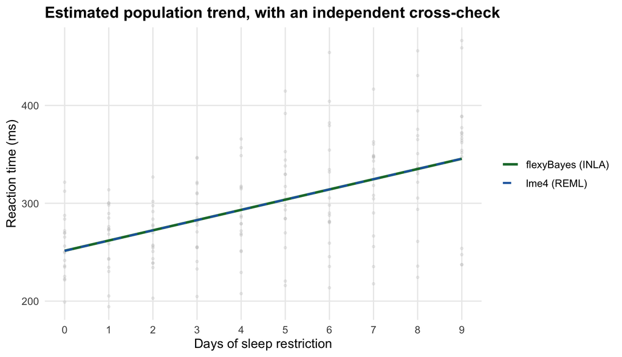

The estimated population trend (solid) over the subject data (grey). The dashed line is an independent lme4 fit, shown as a cross-check; the two population slopes coincide.

```r
b0 <- fx[["(Intercept)", "mean"]]; b1 <- fx[["Days", "mean"]]
lmer_fit <- lme4::lmer(Reaction ~ Days + (1 | Subject), data = sleepstudy, REML = TRUE)
lfx <- lme4::fixef(lmer_fit)
grid <- data.frame(Days = seq(0, 9, length.out = 50))
grid$flexyBayes <- b0 + b1 * grid$Days
grid$lme4 <- lfx[["(Intercept)"]] + lfx[["Days"]] * grid$Days
ggplot(sleepstudy, aes(Days, Reaction)) +
  geom_point(alpha = 0.25, colour = grey_ln, size = 0.8) +
  geom_line(data = grid, aes(Days, flexyBayes, colour = "flexyBayes (INLA)"),
            linewidth = 1.1) +
  geom_line(data = grid, aes(Days, lme4, colour = "lme4 (REML)"),
            linewidth = 0.9, linetype = 2) +
  scale_colour_manual(values = c("flexyBayes (INLA)" = accent,
                                 "lme4 (REML)" = ref_col), name = NULL) +
  scale_x_continuous(breaks = 0:9) +
  labs(x = "Days of sleep restriction", y = "Reaction time (ms)",
       title = "Estimated population trend, with an independent cross-check") +
  theme_wt()
```

## 1.4 Cross-check against a classical fit

A Bayesian fit is more trustworthy when it agrees with an independent estimator on a problem both can handle. **Restricted maximum likelihood (REML)**, the standard frequentist estimator for mixed models, is fitted here with `lme4` (Bates et al., 2015).

```r
cross <- data.frame(
  Term = names(lfx),
  flexyBayes = round(fx[names(lfx), "mean"], 2),
  `lme4 REML` = round(unname(lfx), 2),
  Difference = round(fx[names(lfx), "mean"] - unname(lfx), 3),
  check.names = FALSE
)
knitr::kable(cross, align = "lrrr",
             caption = "Population estimates: flexyBayes against an independent lme4 REML fit.")
```

Population estimates: flexyBayes against an independent lme4 REML fit.

| Term | flexyBayes | lme4 REML | Difference |
| --- | --- | --- | --- |
| (Intercept) | 251.48 | 251.41 | 0.074 |
| Days | 10.45 | 10.47 | -0.017 |

The two methods, one Bayesian and one frequentist, land on the same population estimates. That agreement is the licence to trust the posterior for the next step.

## 1.5 Hand the result to the colleague

The statistician saves the fitted model and a one-line plain-text answer, and passes them on. Nothing else needs to travel.

```r
handoff_dir  <- file.path(tempdir(), "sleep_handoff")
dir.create(handoff_dir, showWarnings = FALSE)
saveRDS(fit, file.path(handoff_dir, "reaction_model.rds"))
answer <- sprintf(
  "Reaction time worsens by %.1f ms/day (95%% credible interval %.1f to %.1f).",
  days_row[["mean"]], days_row[["0.025quant"]], days_row[["0.975quant"]])
writeLines(answer, file.path(handoff_dir, "headline.txt"))
cat(answer, "\n")
```

```
#> Reaction time worsens by 10.5 ms/day (95% credible interval 8.0 to 12.9).
```

# 2 The sleep researcher’s side

This section is for the colleague, who studies sleep rather than statistics. You received two files: a model (`reaction_model.rds`) and a one-line headline (`headline.txt`). You will read them, ask the model one question, and get a number with an uncertainty. You do not fit anything.

```r
install.packages("flexyBayes")          # one time, to open the model
fit <- readRDS("reaction_model.rds")    # the statistician's result
summary(fit)                            # the full posterior summary
```

```r
fit2 <- readRDS(file.path(handoff_dir, "reaction_model.rds"))
cat(readLines(file.path(handoff_dir, "headline.txt")), "\n")
```

```
#> Reaction time worsens by 10.5 ms/day (95% credible interval 8.0 to 12.9).
```

## 2.1 The first question: the daily rate

The colleague’s question is the headline already computed: the daily degradation rate and its uncertainty. They read it straight off the posterior summary, without re-running anything.

```r
fx2 <- summary(fit2)$fixed
```

```
#> Bayesian fit summary  [flexybayes_inla / INLA backend]
#> ------------------------------------------------------------
#> Fixed effects:
#>                 mean     sd 0.025quant 0.5quant 0.975quant     mode kld
#> (Intercept) 251.4795 6.7123   238.3051 251.4792   264.6561 251.4792   0
#> Days         10.4507 1.2570     7.9831  10.4508    12.9179  10.4508   0
#>
#> Hyperparameters:
#>                                                 mean           sd  0.025quant
#> Precision for the Gaussian observations 5.000000e-04 1.000000e-04 4.00000e-04
#> Precision for Subject                   8.509333e+10 7.929682e+10 1.61673e+10
#>                                             0.5quant   0.975quant        mode
#> Precision for the Gaussian observations 5.000000e-04 6.000000e-04 4.00000e-04
#> Precision for Subject                   6.217781e+10 2.955598e+11 3.62784e+10
#>
#> Random effects:
#>   groups: Subject
#> ------------------------------------------------------------
```

```r
sprintf("Per-day change: %.2f ms (95%% credible interval %.2f to %.2f)",
        fx2["Days", "mean"], fx2["Days", "0.025quant"], fx2["Days", "0.975quant"])
```

```
#> [1] "Per-day change: 10.45 ms (95% credible interval 7.98 to 12.92)"
```

## 2.2 The second question: a concrete prediction

A more tangible question for a sleep researcher: **after ten days of restriction, how much slower is a typical person than at the start?** That is ten days of the daily rate.

```r
b1_mean <- fx2["Days", "mean"]
b1_lo   <- fx2["Days", "0.025quant"]
b1_hi   <- fx2["Days", "0.975quant"]
ten_day <- 10 * c(mean = b1_mean, lower = b1_lo, upper = b1_hi)
sprintf("After 10 days: about %.0f ms slower (95%% credible interval %.0f to %.0f ms).",
        ten_day[["mean"]], ten_day[["lower"]], ten_day[["upper"]])
```

```
#> [1] "After 10 days: about 105 ms slower (95% credible interval 80 to 129 ms)."
```

So a typical person reacts roughly 105 milliseconds more slowly after ten days of restricted sleep, and the data are consistent with a slowdown anywhere from about 80 to 129 milliseconds. The colleague has a number and a stated range for their report, and never touched the modelling code.

# 3 Refining the model: an explicit prior

A careful analyst checks whether the answer depends on the default prior. `flexyBayes` takes priors in a readable penalised-complexity syntax through `fb_prior()`. Here the residual scale is given an explicit weakly-informative prior, and the fit is repeated.

```r
fit_prior <- flexybayes(
  fixed   = Reaction ~ Days,
  random  = ~ Subject,
  data    = sleepstudy,
  family  = "gaussian",
  backend = "inla",
  prior   = fb_prior(sigma ~ pc(upper = 60, prob = 0.05)),
  verbose = FALSE, mcmc_verbose = FALSE
)
fxp <- summary(fit_prior)$fixed
```

```
#> Bayesian fit summary  [flexybayes_inla / INLA backend]
#> ------------------------------------------------------------
#> Fixed effects:
#>                 mean     sd 0.025quant 0.5quant 0.975quant     mode kld
#> (Intercept) 251.4775 6.6177   238.4888 251.4771   264.4681 251.4771   0
#> Days         10.4512 1.2393     8.0184  10.4513    12.8836  10.4513   0
#>
#> Hyperparameters:
#>                                               mean      sd 0.025quant
#> Precision for the Gaussian observations     0.0004    0.00     0.0004
#> Precision for Subject                   19573.1645 4064.86 12369.8624
#>                                           0.5quant 0.975quant       mode
#> Precision for the Gaussian observations     0.0004     0.0005     0.0004
#> Precision for Subject                   19301.4352 28267.6032 18985.6967
#>
#> Random effects:
#>   groups: Subject
#> ------------------------------------------------------------
```

```r
sprintf("Days slope: default prior %.2f vs explicit prior %.2f ms/day",
        days_row[["mean"]], fxp["Days", "mean"])
```

```
#> [1] "Days slope: default prior 10.45 vs explicit prior 10.45 ms/day"
```

The population slope is unchanged to two decimal places, so the headline result is robust to this prior choice. The data, not the prior, are driving the population estimate.

# 4 What this looked like end to end

| Stage | Who | What moved |
| --- | --- | --- |
| Specify and fit the model | Statistician | nothing |
| Read the posterior, cross-check against lme4 | Statistician | nothing |
| Save model + headline | Statistician | a small result file |
| Read the headline | Researcher | nothing |
| Ask the model for a 10-day prediction | Researcher | a number + interval |
| Refit with an explicit prior | Statistician | nothing |

One specification, fitted once, answered both a methodological question (the daily rate, with a credible interval) and an applied question (the ten-day prediction), and the answer survived an independent cross-check and a change of prior.

**Tip**

**Try it on your own data.** Three lines fit a mixed model and read the population effect:

```r
fit <- flexybayes(fixed = response ~ x, random = ~ group,
                  data = your_data, family = "gaussian", backend = "inla")
summary(fit)$fixed
```

## 4.1 Acknowledgements and references

The sleepstudy data are reused from the `lme4` package under its GPL licence. The reaction-time study itself, and any empirical claim about sleep, should be cited to Belenky et al. (2003), not to this walkthrough.

- Belenky, G., et al. (2003). Patterns of performance degradation and restoration during sleep restriction and subsequent recovery. *Journal of Sleep Research*, 12(1), 1–12. doi:10.1046/j.1365-2869.2003.00337.x
- Bates, D., et al. (2015). Fitting linear mixed-effects models using lme4. *Journal of Statistical Software*, 67(1), 1–48. doi:10.18637/jss.v067.i01
- Rue, H., et al. (2009). Approximate Bayesian inference for latent Gaussian models by using integrated nested Laplace approximations. *Journal of the Royal Statistical Society: Series B*, 71(2), 319–392. doi:10.1111/j.1467-9868.2008.00700.x
- Burkner, P.-C. (2017). brms: An R package for Bayesian multilevel models using Stan. *Journal of Statistical Software*, 80(1), 1–28. doi:10.18637/jss.v080.i01
- Golding, N. (2019). greta: simple and scalable statistical modelling in R. *Journal of Open Source Software*, 4(40), 1601. doi:10.21105/joss.01601